# Exploration of Football Premier League Dataset

## Preliminary Wrangling

> The dataset contains data and stats about Priemer League matches stats from 2011 to 2019

```python
# import all packages and set plots to be embedded inline
import numpy as np
import pandas as pd
import matplotlib.pyplot as plt
import seaborn as sb
%matplotlib inline
```

> Load in your dataset and describe its properties through the questions below. Try and motivate your exploration goals through this section.

```python
# Load the dataset
df_base = pd.read_csv('pl.csv', encoding ='ISO-8859-1')
df_base.head()
```

|  | PL_id | season | match_week | date | kickoff | referee | stadium | city | attendance | home_team | ... | home_offsides | away_offsides | home_yellows | away_yellows | home_reds | away_reds | home_fouls | away_fouls | home_lineup | away_lineup |
| --- | --- | --- | --- | --- | --- | --- | --- | --- | --- | --- | --- | --- | --- | --- | --- | --- | --- | --- | --- | --- | --- |
| 0 | 7467 | 2011/12 | 1 | 08/13/2011 | 11:00 | Kevin Friend | Ewood Park | Blackburn | 21996 | Blackburn Rovers | ... | 0.0 | 1.0 | 4.0 | 2.0 | 0.0 | 0.0 | 13.0 | 11.0 | Paul Robinson - Míchel Salgado - Martin Olsson... | Wayne Hennessey - Roger Johnson - Richard Stea... |
| 1 | 7468 | 2011/12 | 1 | 08/13/2011 | 11:00 | Lee Mason | Craven Cottage | London | 25700 | Fulham | ... | 5.0 | 4.0 | 2.0 | 4.0 | 0.0 | 0.0 | 10.0 | 19.0 | Mark Schwarzer - John Arne Riise - Philippe Se... | Shay Given - Luke Young - Stephen Warnock - Ri... |
| 2 | 7469 | 2011/12 | 1 | 08/13/2011 | 11:00 | Phil Dowd | Anfield | Liverpool | 45018 | Liverpool | ... | 1.0 | 2.0 | 4.0 | 4.0 | 0.0 | 0.0 | 17.0 | 13.0 | Pepe Reina - José Enrique - Daniel Agger - Jam... | Simon Mignolet - Phil Bardsley - Wes Brown - A... |
| 3 | 7470 | 2011/12 | 1 | 08/13/2011 | 13:30 | Peter Walton | St James' Park | Newcastle | 46894 | Newcastle United | ... | 3.0 | 1.0 | 3.0 | 5.0 | 0.0 | 1.0 | 10.0 | 11.0 | Tim Krul - Fabricio Coloccini - Danny Simpson ... | Wojciech Szczesny - Kieran Gibbs - Bacary Sagn... |
| 4 | 7471 | 2011/12 | 1 | 08/13/2011 | 11:00 | Martin Atkinson | Kiyan Prince Foundation Stadium | London | 15195 | Queens Park Rangers | ... | 3.0 | 1.0 | 3.0 | 5.0 | 0.0 | 1.0 | 10.0 | 11.0 | Paddy Kenny - Fitz Hall - Danny GabbidonOwn -... | Jussi Jääskeläinen - Grétar Steinsson - Paul R... |

5 rows × 62 columns

```python
df_base.info()
```

```
<class 'pandas.core.frame.DataFrame'>
RangeIndex: 3327 entries, 0 to 3326
Data columns (total 62 columns):
 #   Column                      Non-Null Count  Dtype
---  ------                      --------------  -----
 0   PL_id                       3327 non-null   int64
 1   season                      3327 non-null   object
 2   match_week                  3327 non-null   int64
 3   date                        3303 non-null   object
 4   kickoff                     3307 non-null   object
 5   referee                     3327 non-null   object
 6   stadium                     3327 non-null   object
 7   city                        3327 non-null   object
 8   attendance                  3327 non-null   int64
 9   home_team                   3327 non-null   object
```

[output cut: 54 more lines]

```python
# Select the needed columns from our dataset

df_base = df_base[['PL_id','season', 'match_week', 'stadium', 'attendance', 'home_team', 'away_team', 'result',
         'home_score', 'away_score','home_shots','away_shots', 'home_posse','away_posse',
         'home_shotsON', 'away_shotsON', 'home_passes', 'away_passes',
         'home_yellows', 'away_yellows', 'home_reds', 'away_reds']]
df_base.head()
```

|  | PL_id | season | match_week | stadium | attendance | home_team | away_team | result | home_score | away_score | ... | home_posse | away_posse | home_shotsON | away_shotsON | home_passes | away_passes | home_yellows | away_yellows | home_reds | away_reds |
| --- | --- | --- | --- | --- | --- | --- | --- | --- | --- | --- | --- | --- | --- | --- | --- | --- | --- | --- | --- | --- | --- |
| 0 | 7467 | 2011/12 | 1 | Ewood Park | 21996 | Blackburn Rovers | Wolverhampton Wanderers | away | 1 | 2 | ... | 52.0 | 48.0 | 2.0 | 4.0 | 330.0 | 298.0 | 4.0 | 2.0 | 0.0 | 0.0 |
| 1 | 7468 | 2011/12 | 1 | Craven Cottage | 25700 | Fulham | Aston Villa | tie | 0 | 0 | ... | 54.1 | 45.9 | 5.0 | 1.0 | 419.0 | 352.0 | 2.0 | 4.0 | 0.0 | 0.0 |
| 2 | 7469 | 2011/12 | 1 | Anfield | 45018 | Liverpool | Sunderland | tie | 1 | 1 | ... | 60.1 | 39.9 | 3.0 | 4.0 | 480.0 | 316.0 | 4.0 | 4.0 | 0.0 | 0.0 |
| 3 | 7470 | 2011/12 | 1 | St James' Park | 46894 | Newcastle United | Arsenal | tie | 0 | 0 | ... | 37.8 | 62.2 | 1.0 | 2.0 | 320.0 | 548.0 | 3.0 | 5.0 | 0.0 | 1.0 |
| 4 | 7471 | 2011/12 | 1 | Kiyan Prince Foundation Stadium | 15195 | Queens Park Rangers | Bolton Wanderers | away | 0 | 4 | ... | 37.8 | 62.2 | 1.0 | 2.0 | 320.0 | 548.0 | 3.0 | 5.0 | 0.0 | 1.0 |

5 rows × 22 columns

**This dataset is good for visualize the result and compare bewteen the wins of home and away teams. But, there are columns describe the same features as home_shots and away_shots, so we need to make new dataframe in an efficient way.**

- So we will have two shapes of the dataset.

```python
# specify the new columns for the new dataframe
cols = ['PL_id','season','match_week','stadium','attendance', 'team',
        'result', 'scored', 'shots', 'shots_on', 'posse', 'passes', 'yellows','reds']
```

```python
# Create new Dataframe called home_tdf for the home teams stats

home_tdf = pd.DataFrame(columns=cols)
home_cols = ['PL_id','season', 'match_week', 'stadium', 'attendance', 'home_team',
             'result', 'home_score', 'home_shots', 'home_shotsON', 'home_posse',
             'home_passes', 'home_yellows','home_reds']
home_tdf[cols] = df_base[home_cols]

home_tdf.loc[home_tdf['result']=='home','result'] = 'win'
home_tdf.loc[home_tdf['result']=='away','result'] = 'lose'
home_tdf['team_hospitality'] = 'Home'
home_tdf.head()
```

|  | PL_id | season | match_week | stadium | attendance | team | result | scored | shots | shots_on | posse | passes | yellows | reds | team_hospitality |
| --- | --- | --- | --- | --- | --- | --- | --- | --- | --- | --- | --- | --- | --- | --- | --- |
| 0 | 7467 | 2011/12 | 1 | Ewood Park | 21996 | Blackburn Rovers | lose | 1 | 17.0 | 2.0 | 52.0 | 330.0 | 4.0 | 0.0 | Home |
| 1 | 7468 | 2011/12 | 1 | Craven Cottage | 25700 | Fulham | tie | 0 | 15.0 | 5.0 | 54.1 | 419.0 | 2.0 | 0.0 | Home |
| 2 | 7469 | 2011/12 | 1 | Anfield | 45018 | Liverpool | tie | 1 | 14.0 | 3.0 | 60.1 | 480.0 | 4.0 | 0.0 | Home |
| 3 | 7470 | 2011/12 | 1 | St James' Park | 46894 | Newcastle United | tie | 0 | 8.0 | 1.0 | 37.8 | 320.0 | 3.0 | 0.0 | Home |
| 4 | 7471 | 2011/12 | 1 | Kiyan Prince Foundation Stadium | 15195 | Queens Park Rangers | lose | 0 | 8.0 | 1.0 | 37.8 | 320.0 | 3.0 | 0.0 | Home |

```python
# Create new Dataframe called away_tdf for the away teams stats

away_tdf = pd.DataFrame(columns=cols)
away_cols = ['PL_id','season', 'match_week', 'stadium', 'attendance', 'away_team',
             'result', 'away_score', 'away_shots', 'away_shotsON', 'away_posse',
             'away_passes', 'away_yellows','away_reds']
away_tdf[cols] = df_base[away_cols]

away_tdf.loc[away_tdf['result']=='away','result'] = 'win'
away_tdf.loc[away_tdf['result']=='home','result'] = 'lose'
away_tdf['team_hospitality'] = 'Away'
away_tdf.head()
```

|  | PL_id | season | match_week | stadium | attendance | team | result | scored | shots | shots_on | posse | passes | yellows | reds | team_hospitality |
| --- | --- | --- | --- | --- | --- | --- | --- | --- | --- | --- | --- | --- | --- | --- | --- |
| 0 | 7467 | 2011/12 | 1 | Ewood Park | 21996 | Wolverhampton Wanderers | win | 2 | 15.0 | 4.0 | 48.0 | 298.0 | 2.0 | 0.0 | Away |
| 1 | 7468 | 2011/12 | 1 | Craven Cottage | 25700 | Aston Villa | tie | 0 | 7.0 | 1.0 | 45.9 | 352.0 | 4.0 | 0.0 | Away |
| 2 | 7469 | 2011/12 | 1 | Anfield | 45018 | Sunderland | tie | 1 | 14.0 | 4.0 | 39.9 | 316.0 | 4.0 | 0.0 | Away |
| 3 | 7470 | 2011/12 | 1 | St James' Park | 46894 | Arsenal | tie | 0 | 11.0 | 2.0 | 62.2 | 548.0 | 5.0 | 1.0 | Away |
| 4 | 7471 | 2011/12 | 1 | Kiyan Prince Foundation Stadium | 15195 | Bolton Wanderers | win | 4 | 11.0 | 2.0 | 62.2 | 548.0 | 5.0 | 1.0 | Away |

```python
# Add the two dataframes for home and away

df_mod = away_tdf.append(home_tdf,ignore_index=True)
df_mod.head()
```

|  | PL_id | season | match_week | stadium | attendance | team | result | scored | shots | shots_on | posse | passes | yellows | reds | team_hospitality |
| --- | --- | --- | --- | --- | --- | --- | --- | --- | --- | --- | --- | --- | --- | --- | --- |
| 0 | 7467 | 2011/12 | 1 | Ewood Park | 21996 | Wolverhampton Wanderers | win | 2 | 15.0 | 4.0 | 48.0 | 298.0 | 2.0 | 0.0 | Away |
| 1 | 7468 | 2011/12 | 1 | Craven Cottage | 25700 | Aston Villa | tie | 0 | 7.0 | 1.0 | 45.9 | 352.0 | 4.0 | 0.0 | Away |
| 2 | 7469 | 2011/12 | 1 | Anfield | 45018 | Sunderland | tie | 1 | 14.0 | 4.0 | 39.9 | 316.0 | 4.0 | 0.0 | Away |
| 3 | 7470 | 2011/12 | 1 | St James' Park | 46894 | Arsenal | tie | 0 | 11.0 | 2.0 | 62.2 | 548.0 | 5.0 | 1.0 | Away |
| 4 | 7471 | 2011/12 | 1 | Kiyan Prince Foundation Stadium | 15195 | Bolton Wanderers | win | 4 | 11.0 | 2.0 | 62.2 | 548.0 | 5.0 | 1.0 | Away |

```python
df_mod.info()
```

```
<class 'pandas.core.frame.DataFrame'>
RangeIndex: 6654 entries, 0 to 6653
Data columns (total 15 columns):
 #   Column            Non-Null Count  Dtype
---  ------            --------------  -----
 0   PL_id             6654 non-null   int64
 1   season            6654 non-null   object
 2   match_week        6654 non-null   int64
 3   stadium           6654 non-null   object
 4   attendance        6654 non-null   int64
 5   team              6654 non-null   object
 6   result            6654 non-null   object
 7   scored            6654 non-null   int64
 8   shots             6654 non-null   float64
 9   shots_on          6654 non-null   float64
 10  posse             6654 non-null   float64
 11  passes            6654 non-null   float64
 12  yellows           6654 non-null   float64
 13  reds              6654 non-null   float64
 14  team_hospitality  6654 non-null   object
dtypes: float64(6), int64(4), object(5)
memory usage: 779.9+ KB
```

```python
df_base.to_csv('datasets/pl_clean_base.csv', encoding='utf-8',index=False)
df_mod.to_csv('datasets/pl_clean_modified.csv', encoding='utf-8',index=False)
```

### What is the structure of your dataset?

- df_base

  > There are 3327 matches from the Premier League matches from 2011 to 2019, it has 22 feature as season, match week, stadium, attendance, home_team, away_team and also the scored goals, shots , passes, yellow and red cards for each team (home and Away) in the match, most of features are numeric, but features as season, stadium, home_team, away_team and result are categorical.
- df_mod

  > This dataset has twice the number if rows of the df_base dataset, because every match has split to two rows, each row describe the stats of one oof two teams (Home / Away), but it has less columns. It has 6654 rows, each columns will be described below.
- Columns:
  1. season: The year of the season. {Categorical}
  2. match_week: The match week number. {Numeric}
  3. stadium: The name of the stadium where the match was played in. {Categorical}
  4. attendance: The number of fans attended the match at the stadium. {Numeric}
  5. team: Name of the team. {Categorical}
  6. result: The result of the match realative to the team (win, lose, tie). {Categorical}
  7. scored: The number of goals to the mentioned team. {Numeric}
  8. shots: The number of shots of the mentioned team. {Numeric}
  9. shots_on: The number of shots on target of the mentioned team. {Numeric}
  10. posse: The percentange of ball possession of the mentrioned team. {Numeric}
  11. passes: The number of passes in the match related to the mentioned team. {Numeric}
  12. yellows: The number of yellow cards to the montioned team. {Numeric}
  13. reds: The number of red cards to the montioned team. {Numeric}
  14. team_hospitality: it Tells that the match is Home or Away to the mentioned team. {Categorical}

### What is/are the main feature(s) of interest in your dataset?

> I think we need to explore to know what features that scored goals, and result are depending on

### What features in the dataset do you think will help support your investigation into your feature(s) of interest?

> I expect that the match is home or away is affects the results, and also there is more features will help as attendence, shots, possession rate, and passes.

## Univariate Exploration

> In this section, investigate distributions of individual variables. If you see unusual points or outliers, take a deeper look to clean things up and prepare yourself to look at relationships between variables.

```python
order_dic = {'team_hospitality':['Home','Away'], 'result':['win','tie','lose']}
```

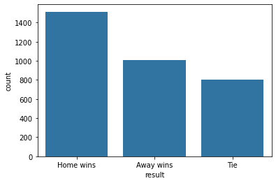

```python
# Countplot for the winning team in the matchs
base_color = sb.color_palette()[0]
res_order = ['home', 'away', 'tie']
x_ticks_labels = ['Home wins', 'Away wins', 'Tie']
sb.countplot(data=df_base, x='result', order=res_order, color=base_color);
plt.xticks([0,1,2], x_ticks_labels);
```

> We see here that the team that plays in his stadium (Home Team) has higher proportion to win the match

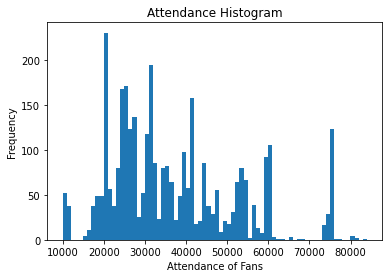

```python
# Histogram for Attendance of fans
bins = np.arange(9980, 83222+1000, 1000)

plt.hist(data=df_base, x='attendance',bins=bins);
plt.title('Attendance Histogram')
plt.xlabel('Attendance of Fans');
#plt.xscale('log')
plt.ylabel("Frequency");
#plt.xticks([10000, 18500, 30000, 40000], ['10000', '18500', '30000', '40000'])
```

> There are very large frequency at specific regoins, i think because that each stadium has specific seating capacity, and most of the matches the stadium is full capicty.

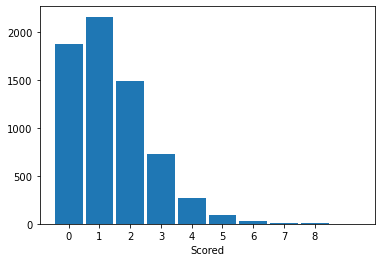

```python
# histogram for scored Goals in the matches for each team.
bins = np.arange(-0.5,9.5+1 , 1)
plt.hist(data=df_mod, x='scored', bins=bins, rwidth = 0.9);
plt.xticks(np.arange(0, 9, 1));
plt.xlabel('Scored')
```

> We observe here that the distribution is right skewed, most of the teams score 1 or 2 or 3 goals, or they dont score a goal at all.

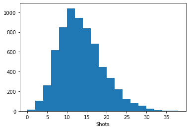

```python
# Histogram for number of shots in the match for each team.
bins = np.arange(0, 40, 2)
plt.hist(data=df_mod, x='shots', bins=bins);
plt.xlabel('Shots');
```

> As noticed here, the distribution is slightly right skewed. most of shots data is between 7 and 16 shots.

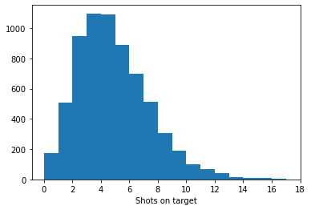

```python
# Histogram for number of shots on target in the match for each team.
bins = np.arange(0, 18,1)

plt.hist(data=df_mod, x='shots_on', bins=bins);
plt.xticks(np.arange(0,19,2));
plt.xlabel('Shots on target');
```

> We here see, that the histogram is right skewed, the team has higher proportion to shot on target between 2 to 6 shots in a match. it is reasonable that the mean of shots_on target be lower than all shots.

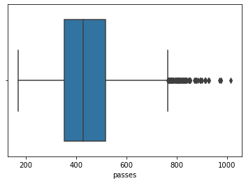

```python
sb.boxplot(data=df_mod, x='passes');
```

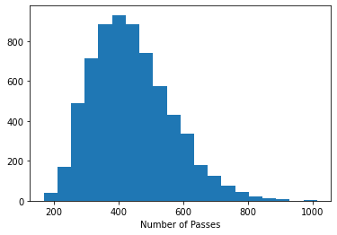

```python
# Histogram for number of passes in the match for each team.
plt.hist(data=df_mod, x='passes', bins =20);
plt.xlabel('Number of Passes');
```

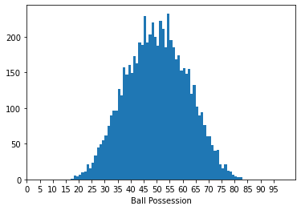

```python
# Histogram for number of ball possession in the match for each team.
bins = np.arange(10, 100,1)

plt.hist(data=df_mod, x='posse',bins=bins);
plt.xticks(np.arange(0,100,5));
plt.xlabel('Ball Possession');
```

> as we see, it is normal distribution, it is reasonable to be normal distrbution because in the second datafram(df_mod), the match is repeated twice (one with home team stats and one with away team stats). Since the in every match the sum of possession for the two teams is 100, the distribution must be normal, but as noticed, around 50 there are sparks, in football match it is not very common for each team in the match to get 50 at ball possession,.

```python
df_mod.describe()
```

|  | PL_id | match_week | attendance | scored | shots | shots_on | posse | passes | yellows | reds |
| --- | --- | --- | --- | --- | --- | --- | --- | --- | --- | --- |
| count | 6654.000000 | 6654.000000 | 6654.000000 | 6654.000000 | 6654.000000 | 6654.000000 | 6654.000000 | 6654.000000 | 6654.000000 | 6654.000000 |
| mean | 18026.061617 | 19.195972 | 36751.217613 | 1.370304 | 13.088969 | 4.371055 | 50.000000 | 441.519838 | 1.640968 | 0.070784 |
| std | 12912.027961 | 10.972907 | 15450.261664 | 1.251938 | 5.543744 | 2.511685 | 11.677613 | 123.199263 | 1.252400 | 0.265695 |
| min | 7467.000000 | 1.000000 | 9980.000000 | 0.000000 | 0.000000 | 0.000000 | 17.100000 | 169.000000 | 0.000000 | 0.000000 |
| 25% | 9302.250000 | 10.000000 | 25083.750000 | 0.000000 | 9.000000 | 3.000000 | 41.600000 | 352.000000 | 1.000000 | 0.000000 |
| 50% | 12258.000000 | 19.000000 | 32072.000000 | 1.000000 | 12.000000 | 4.000000 | 50.000000 | 428.000000 | 1.000000 | 0.000000 |
| 75% | 22556.750000 | 28.000000 | 45451.750000 | 2.000000 | 16.000000 | 6.000000 | 58.400000 | 517.000000 | 2.000000 | 0.000000 |
| max | 46894.000000 | 40.000000 | 83222.000000 | 9.000000 | 44.000000 | 17.000000 | 82.900000 | 1015.000000 | 9.000000 | 2.000000 |

### Discuss the distribution(s) of your variable(s) of interest. Were there any unusual points? Did you need to perform any transformations?

> Until now there is no unusual distribution except attendance feature, we saw that the team which plays the match on his stadium (Home) has higher chance to win the match.  
> The distrubution of (shots, shots_on, passes) is right skewed.  
> Attendance distrubution at some values is very high relative to his around values. i think its because each stadium has limit to the seats capicity in it, and most of time the stadium is full capicity.

### Of the features you investigated, were there any unusual distributions? Did you perform any operations on the data to tidy, adjust, or change the form of the data? If so, why did you do this?

> There are two forms to the database (df_base, df_mod), the df_mod is drived from df_base, each row in the main dataset is describe a match and stats about home team and away team in one row, it is alot of columns, we can reduce the number of columns by divide the one row to two rows each row describe the stats for one team in the match, and add new column called (team_hospitality), to determine is the team was playing at Home or Away, i will make it easier for ploting and visualizing.

## Bivariate Exploration

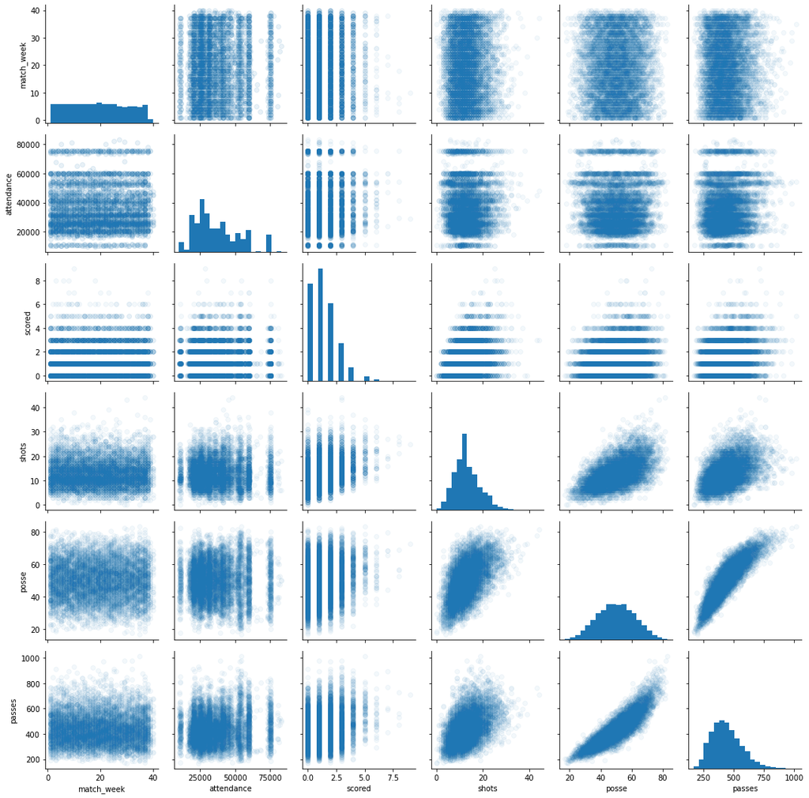

```python
numeric_vars = ['match_week','attendance','scored','shots','posse','passes']
g = sb.PairGrid(data = df_mod, vars = numeric_vars)
g = g.map_diag(plt.hist, bins = 20);
g.map_offdiag(plt.scatter, alpha=1/20);
```

> We notice that there is a relation between **passes** and **posse**, also relation between **posse** and **shots**. there some relations must be view them individualy to take a closer look.

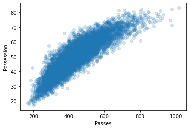

```python
# Scatter plot between Passes and Possession
plt.scatter(data=df_mod, x='passes', y='posse', alpha=1/5)
plt.xlabel('Passes')
plt.ylabel('Possession');
```

> You will notice the strong postive correlation between the number of passes and the percentage of ball possession in the match. it is making sense, if the team is passes the ball alot, the team will get high ball possession.

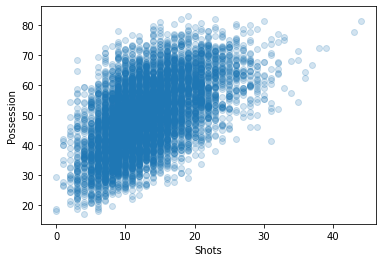

```python
# Scatter plot between shots and Possession
plt.scatter(data=df_mod, x='shots', y='posse', alpha=1/5)
plt.xlabel('Shots')
plt.ylabel('Possession');
```

> As shown in the scatter plot between shots and possession, there are postive relation between them.

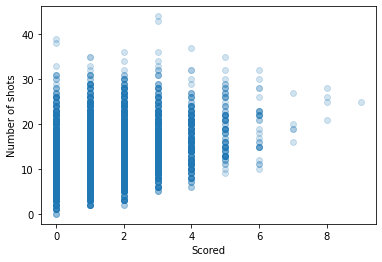

```python
# Scatter plot between scored goals and number of shots for each team in the match.
sb.regplot(data=df_mod, x='scored', y='shots', scatter_kws={"alpha":1/5},fit_reg=False);
plt.xlabel('Scored')
plt.ylabel('Number of shots')
```

> It is resonable for this scatter plot between scored goals and number of shots to be postive correlated, when the team shots a large number of balls, he is having a great chance to score more goals.

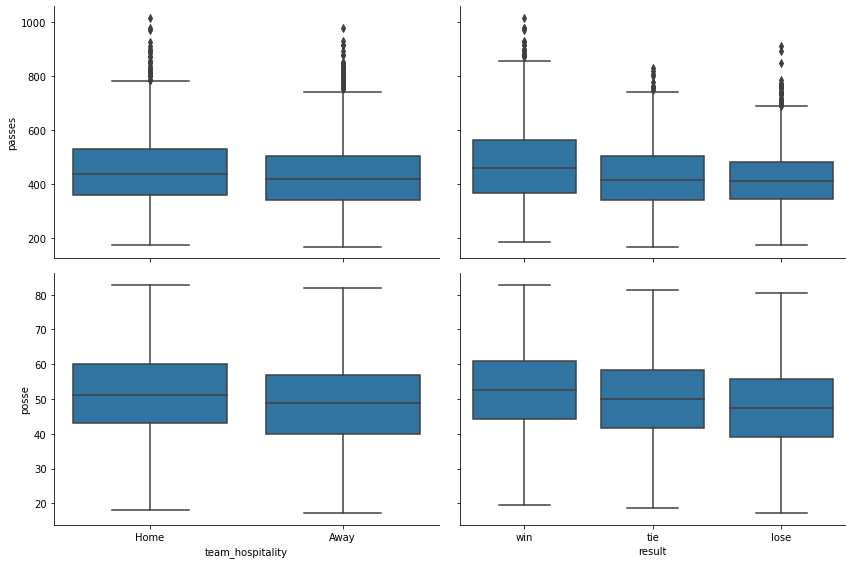

```python
def boxgrid(x, y, **kwargs):
    """ Quick hack for creating box plots with seaborn's PairGrid. """
    order_dic = kwargs['order']
    default_color = sb.color_palette()[0]

    sb.boxplot(x=x, y=y, color = default_color, order=order_dic[x.name]);


plt.figure(figsize = [10, 10]);
g = sb.PairGrid(data = df_mod, y_vars = ['passes', 'posse'], x_vars = ['team_hospitality', 'result'],
                height = 4, aspect = 1.5);
g.map(boxgrid, order = order_dic);
plt.show();
```

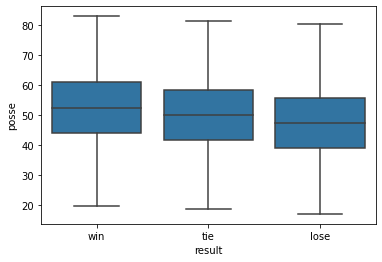

```python
# boxplot between Result and possession
sb.boxplot(data=df_mod, y='posse', x='result', color=base_color);
```

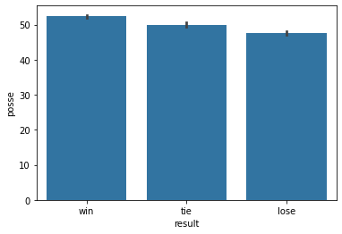

```python
# barplot between Result and possession
sb.barplot(data=df_mod, y='posse', x='result', color=base_color);
```

> Here, The teams with high possession on ball has higher chance to win the match, as we see the differnce between win and lose is small, so it is not a rule. sometimes the losing team has ball possesion higher than the winning team.

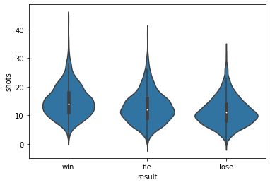

```python
# violinplot between Result and shots.
sb.violinplot(data=df_mod, y='shots', x='result', color=base_color);
```

> As we see in the violin plot, the winner is most probably has higher number of shots. Also here the differnce between them is very close, but in our dataset the winning team has high records that the losing team didn't reach it.

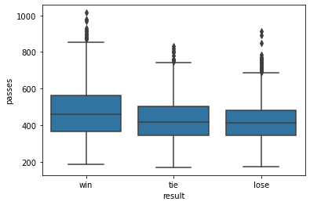

```python
sb.boxplot(data=df_mod, y='passes', x='result', color=base_color);
```

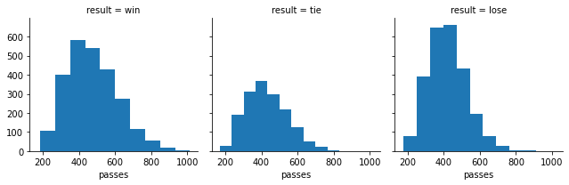

```python
g = sb.FacetGrid(data=df_mod, col='result',);
g.map(plt.hist, 'passes');
```

```python
(df_base.home_passes > df_base.away_passes).mean()
```

```
0.5266005410279531
```

> As we see in the facetplot and boxplot between result and passes, the winning team has higher probability to make more passes than the losing team. also the differnce is very close.

```python
(df_base.home_shots > df_base.away_shots).mean()
```

```
0.604448452058912
```

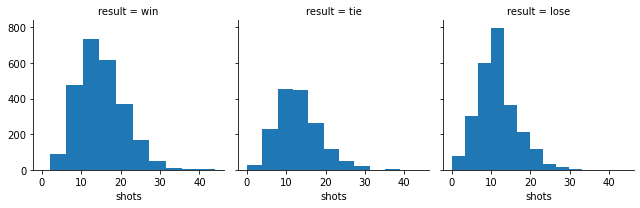

```python
g = sb.FacetGrid(data=df_mod, col='result',);
g.map(plt.hist, 'shots');
```

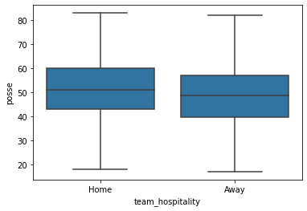

```python
sb.boxplot(data=df_mod, y='posse', x='team_hospitality', color=base_color, order=order_dic['team_hospitality']);
```

> We observe that the team that play at home has higher possession in the match than who plays at away stadium.

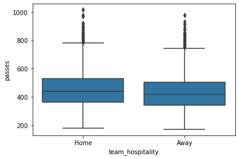

```python
sb.boxplot(data=df_mod, y='passes', x='team_hospitality', color=base_color, order=order_dic['team_hospitality']);
```

> The team at home passes more number of balls than the other team.

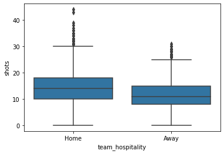

```python
sb.boxplot(data=df_mod, y='shots', x='team_hospitality', color=base_color, order=order_dic['team_hospitality']);
```

> Most probably, the team plays at home will have more number of shots than the other team.

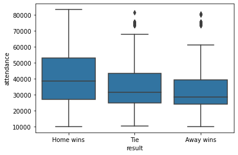

```python
res_order = ['home', 'tie', 'away']
x_ticks_labels = ['Home wins', 'Tie', 'Away wins']
sb.boxplot(data=df_base, x='result', y='attendance',color=base_color, order=res_order)
plt.xticks([0, 1, 2], x_ticks_labels);
```

> We observe that the teams that plays at home with a large number of fans attended in the stadium, the home team has more chance to win the match than the away team.

```python
df_mod["shots_prop"] = df_mod.shots_on / df_mod.shots * 100
```

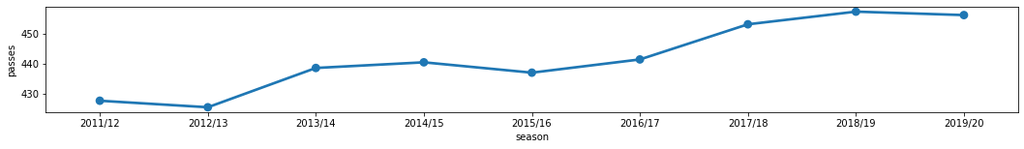

```python
plt.figure(figsize=(18,2))

sb.pointplot(data = df_mod, x = 'season', y = 'passes', ci=None)
#plt.ylim((0,15))
```

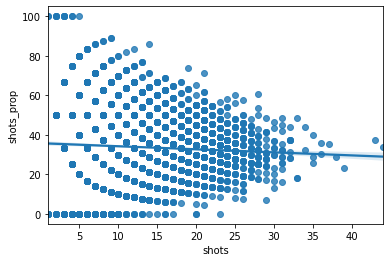

```python
sb.regplot(data=df_mod, x='shots', y='shots_prop')
```

[output not shown]

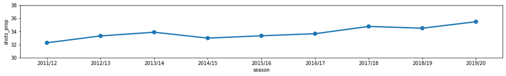

```python
plt.figure(figsize=(18,2))

x = sb.pointplot(data = df_mod, x = 'season', y = 'shots_prop', ci=None)
plt.ylim((30, 38))
```

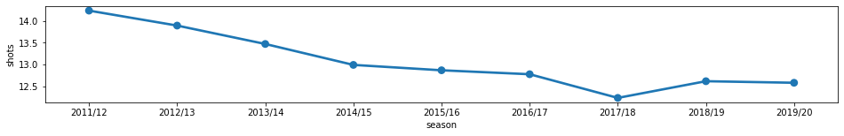

```python
plt.figure(figsize=(16,2))
x = sb.pointplot(data = df_mod, x = 'season', y = 'shots', ci=None)
```

### Talk about some of the relationships you observed in this part of the investigation. How did the feature(s) of interest vary with other features in the dataset?

> As shown previously, - there is a postive relation between number of shots and the number of scored goals. The winner team has higher probability to get more ball possession in the game. Also for passes and shots, the winning team has high chance to get more number than the losing team.  
> The teams that plays at home stadium most probably make more number of passes and shots than the other team, also more ball possesion than the away team.  
> The plot between the attendance and the result (who win the match -Home or Away-) is interesting, it shows that the home team has higher chance to win the match if the attendance in the home team stadium is high, and the away team can win the match when the attendance in the stadium is low.

> The differance between the winning and losing teams in all comparison is very small, but the winning team has higher values in ball possession, passes and shots. the same case at home team and away team, The differances between them are very small, but the home team outperforms the other team.

### Did you observe any interesting relationships between the other features (not the main feature(s) of interest)?

> Scatter plot between Possession and passes is strongly postive corrolated to each other, also possession and shots have postive relation between each other.

## Multivariate Exploration

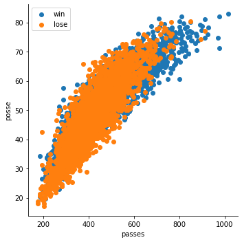

```python
g = sb.FacetGrid(data=df_mod, hue='result', height=5, hue_order=['win', 'lose'],)
g.map(plt.scatter, 'passes', 'posse')
plt.legend();
```

> as we see, win and lose are overlaped in the plot but at high values the "win" outperforms in passes and possession.

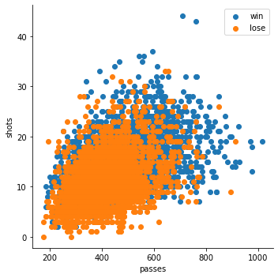

```python
g = sb.FacetGrid(data=df_mod, hue='result', height=5,hue_order=['win', 'lose'],)
g.map(plt.scatter, 'passes', 'shots')
plt.legend();
```

> The figure descibes that the the team that has high number of shots and passes has higher chance to win the game.

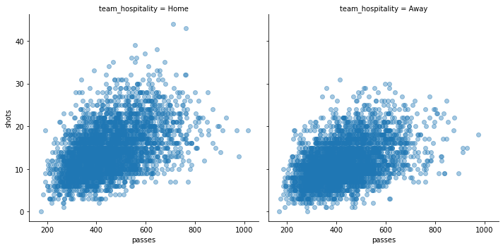

```python
# scatter plots between shots and passes, one plot is for Home teams only and the other plot is for Away teams.
g = sb.FacetGrid(data=df_mod, col='team_hospitality', height=5, col_order=order_dic['team_hospitality'],)
g.map(plt.scatter, 'passes', 'shots', alpha=0.4);
```

> The home team has higher propability to have higher number of shots and passes than the other team in the match.

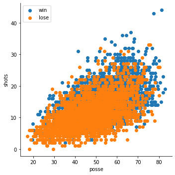

```python
g = sb.FacetGrid(data=df_mod, hue='result', height=5,hue_order=['win', 'lose'],)
g.map(plt.scatter, 'posse', 'shots', alpha=1);
plt.legend();
```

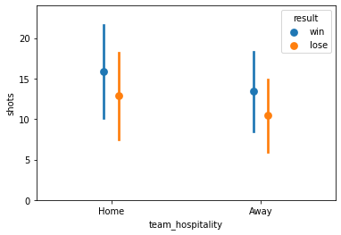

```python
sb.pointplot(data = df_mod, x = 'team_hospitality', y = 'shots',order=order_dic['team_hospitality'],ci='sd',
           hue = 'result', hue_order=['win', 'lose'], linestyles = '', dodge=0.1)
plt.ylim((0,24));
```

> it is obviuos that the winner of the team has average shots more than the losing team, whatever the winning team is playing at home or away.

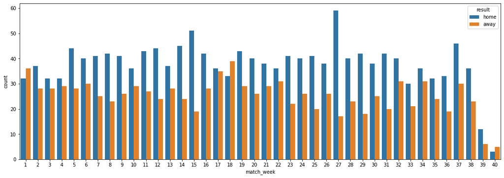

```python
plt.figure(figsize=(18,6))
sb.countplot(data=df_base, x='match_week', hue='result', hue_order=['home', 'away'], )
```

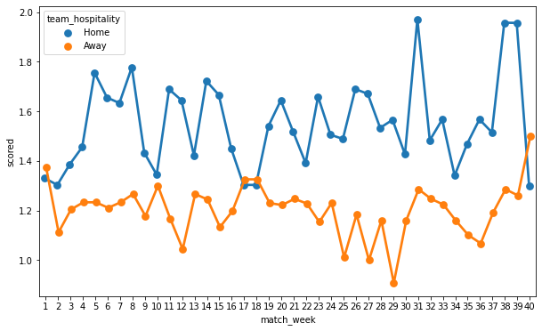

```python
plt.figure(figsize=(10,6))

sb.pointplot(data = df_mod, x = 'match_week', y = 'scored',
             hue = 'team_hospitality', hue_order=['Home', 'Away'], dodge=0.1, ci=None)
#plt.ylim((0,2))
```

> As we see, the home team score more than the away team at most of weeks, bu there are weeks where the away teams overcome the home team. like week 1 , 17, 18 and 40.  
> **Note**: The premier league is consists of 38 weeks, but how we have weeks 39 and 40, sometimes some matches postponed to the last week or after that.

### Were there any interesting or surprising interactions between features?

> There are some weeks that the away team overcome the home team in scored goals.